# Fundamentos de los métodos estadísticos

En control de calidad, se utilizan métodos estadísticos a partir de muestras para hacer inferencias sobre la población. Para aplicar técnicas estadísticas como pruebas de hipótesis, estimación, diseño experimental y análisis de regresión, es fundamental comprender los fundamentos de estos métodos estadísticos.

En este capítulo, estudiaremos los fundamentos de los métodos estadísticos, con el objetivo de que el estudiante sea capaz de hacer lo siguiente:

- Explicar las propiedades de las variables aleatorias y las distribuciones de probabilidad.
- Explicar la distribución uniforme y realizar cálculos de probabilidad.
- Explicar la distribución exponencial y realizar cálculos de probabilidad.
- Explicar la distribución bidimensional y la covarianza, y realizar cálculos de probabilidad.
- Explicar la ley de los grandes números y el teorema del límite central

[Audio_1](https://drive.google.com/file/d/13r0soc-Bzg-rNoky-Fm3xHCLqj8DdlR2/view?usp=drive_link)

```python
import os

try:
  os.chdir('../Python/QCKentei')
except:
  pass

path = os.getcwd()
```

```python
import numpy as np
import pandas as pd
import matplotlib.pyplot as plt
from scipy.stats import binom, norm
import japanize_matplotlib
```

## 03-01 Variable aleatoria y distribución de probabilidad

確率変数と確率分布

### 1. Variable aleatoria y distribución de probabilidad

Se extrae una muestra de la población y se obtienen datos al medir sus características de caridad. Además, los datos siempre variarán cada vez que se extraiga una muestra. A una cantidad o número que, como se mencionó, solo se puede determinar mediante muestreo y medición, se le denomina **variable aleatoria**. La expresión que describe las probabilidades de que una variable aleatoria X tome sus diferentes valores se conoce como **distribución de probabilidad**.

#### (1) Variable alatoria discreta

離散型確率変数

Cuando los valores posibles de una variable aleatoria son **discretos**, como $ x_1, x_2, ... $ se expresan usando una **función de probabilidad $ P_i $, la cual posee las siguientes propiedades:

1. $ p_i \geq 0, i = 1, 2, ... $
2. $ p_i = P_r(X=x_i), i= 1, 2, ... $
3. $ \sum_i p_i = 1 $

#### (2) Variable aleatoria continua

連続型確率変数

Una **distribución de probabilidad** donde los valores posibles son continuos se expresa utilizando una **función de densidad de probabilidad** $ f(x) $, la cual posee las siguientes propiedades:

1. $ f(x) \geq 0 $
2. $ P_r( a < x \leq b) = \int_a^b f(x) dx $
3. $ \int_{\infty}^{\infty} $ f(x)dx = 1

#### Estandarización:

標準化

$ U = \frac{X - \mu}{\sigma} $

#### Distribución normal estándar:

標準正規分布

$ N(0, 1^2) $

[Audio_2](https://drive.google.com/file/d/1fpmJLodIJ_HgK9wbj04kdom8tJx0hI1G/view?usp=drive_link)

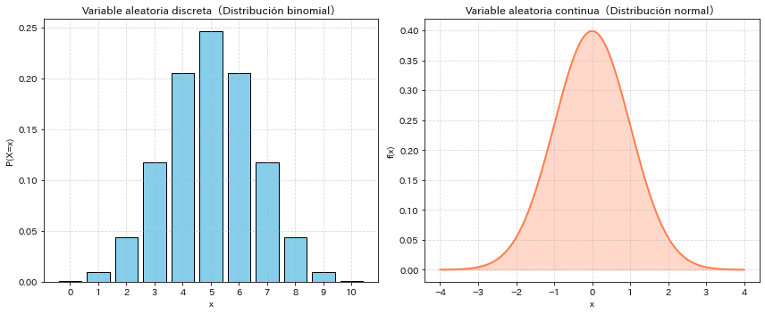

```python
# Configuración de la figura
fig, axs = plt.subplots(1, 2, figsize=(12, 5))

# ------------------------
# 1. Variable aleatoria discreta （ej.：distribución binomial）
# ------------------------
n, p = 10, 0.5  # Número de ensayos n, Probabilidad de éxito p
x_discrete = np.arange(0, n+1)
pmf = binom.pmf(x_discrete, n, p)

axs[0].bar(x_discrete, pmf, color='skyblue', edgecolor='black')
axs[0].set_title("Variable aleatoria discreta（Distribución binomial）")
axs[0].set_xlabel("x")
axs[0].set_ylabel("P(X=x)")
axs[0].set_xticks(x_discrete)
axs[0].grid(True, linestyle="--", alpha=0.5)

# ------------------------
# 2. Variable aleatoria continua（ej.：Distribución normal）
# ------------------------
mu, sigma = 0, 1  # Media y desviación estándar
x_continuous = np.linspace(-4, 4, 400)
pdf = norm.pdf(x_continuous, mu, sigma)

axs[1].plot(x_continuous, pdf, color='coral', lw=2)
axs[1].fill_between(x_continuous, pdf, color='coral', alpha=0.3)
axs[1].set_title("Variable aleatoria continua（Distribución normal）")
axs[1].set_xlabel("x")
axs[1].set_ylabel("f(x)")
axs[1].grid(True, linestyle="--", alpha=0.5)

# Mostrar la figura completa
plt.tight_layout()
plt.show()
```

### 2. Valor esperado de la variable aleatoria

確率変数の期待値と分散

La esperanza matemática (o valor esperado) y la varianza son conceptos fundamentales que se utilizan indispensablemente en la técnica estadísticas, y en las distribuciones de probabilidad, caracterizan dichas distribuciones. La esperanza matemática E(X) es lo que indica el centro de una distribución de probabilidad, mientras que la varianza V(X) muestra la dispersión de dicha distribución.

#### (1) Esperanza matemática o Valor esperado

期待値

#### 1. Para el caso de variables aleatorias discretas.

離散型確率変数の場合

$ E(X) = \sum_i x_i p_i = \mu $

$ \bar{x} = \frac{1}{N} \sum_{i=1}^k c_if_i = \sum_{i=1}^k (\frac{f_i}{N}) $

$ E|g(X)| = \sum_i g(x_i) p_i $

#### 2. Para el caso de variables aleatorias continuas.

連続型確率変数の場合

$ E(X) = \int_{- \infty}^{\infty} x f(x) dx = \mu $

$ E|g(X)| = \int_{- \infty}^{\infty} g(x) f(x) dx $

#### 3. Propiedades del valor esperado:

期待値の性質

$ E(aX + b) = aE(X) + b $

$ E(aX + bY) = aE(X) + bE(Y) $

#### (2) Varianza poblacional:

分散

#### 1. Varianza

$ V(X) = E|(X - \mu)^2| = \sigma^2 $

$ V(X) = E|(x - \mu)^2| = E(X^2) - \mu^2 $

#### 2. Propiedades de la varianza.

分散の性質

$ V(aX+b) = a^2V(X) $

**Aditividad de la varianza** 分散の加法性

$ V(X+Y) = V(X)+V(Y) $

$ V(X-Y)=V(X)+V(Y) $

[Audio_3](https://drive.google.com/file/d/1kKRxf0mOp1TCAxDb2ozsDAe38OyY02ZT/view?usp=drive_link)

## 03-02 Distribución uniforme

一様分布

### 1. Distribución uniforme

**La distribución uniforme** es una distribución en la que la densidad de probabilidad toma un valor constante de $ 1/(b-a) $ en el intervalo (a,b).

- $ f(x) = 1/h \qquad (0<x<h) $
- $ f(x) = 0 \qquad (x \leq 0, x \geq h) $

$ E(X) = \int_{0}^{h} x \frac{1}{h} dx = \bigl[ \frac{x^2}{2h} \bigr]_{0}^{h} = \frac{h}{2} $

$ E(X^2) = \int_{0}^{h} x^2 \frac{1}{n} dx = \bigl[ \frac{x^2}{3h} \bigr]_0^h = \frac{h^2}{3} $

$ V(X) = E|(X-\mu)^2| = E(X^2) - |E(X)|^2 = \frac{h^2}{3} - (\frac{h}{2})^2 = \frac{h^2}{12} $

$ D(x) = \sqrt{V(X)} = \frac{h}{2 \sqrt{3}}$

### 2. Probabilidad de la distribución

一様分布の確率

[Audio_4](https://drive.google.com/file/d/1aQYVKOwIAMrIt-Wp_9Oub6rN_xyQsRO-/view?usp=drive_link)

## 3.1

確率変数Xが区間(0,4)の一様分布に従うとき、Xの期待値、分散、標準偏差を求めよ。また、確率変数Xが区間(1,3)に入る確率を求めよ。

Sea la variable aleatoria X que sigue una distribución uniforme en el intervalo (0,4), calcule el valor esperado, la varianza y la desviación estándar de X. Además, calcule la probabilidad de que la variable aleatoria X esté en el intervalo (1,3).

Función de Densidad de Probabilidad:

f(x) = uniform.pdf(x, loc=a, scale=b-a)

- $ a = 0, \qquad b= 4 $

Valor Esperado:

$ E(x) = (a + b)/2 = 2.00 $

Varianza:

$ V(x) = (b-a)^2/12 = 1.33 $

Desviacón estándar:

$ D(x) = \sqrt{V(x)} = 1.15 $

Probabilidad

$ Pr(1 < X \leq 3) = $ uniform.cdf(3, loc=a, scale=b-a) - uniform.cdf(1, loc=a, scale=b-a)

```
Valor esperado: 2.00
Varianza: 1.33
Desviación estándar: 1.15
Probabilidad de que la variable aleatoria esté en el intervalo (1,3): 0.50
```

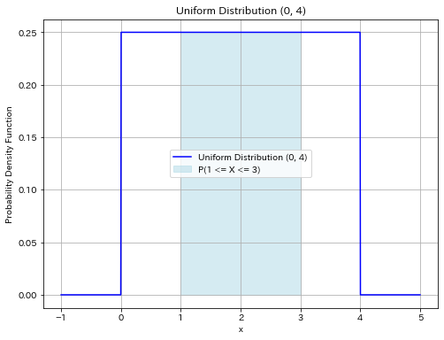

```python
from scipy.stats import uniform

# Parámetros
a, b = 0, 4  # Rango de distribución uniforma (0, 4)

# Valor esperado, Varianza, Desviación estándar
mean = (a + b) / 2
variance = ((b - a) ** 2) / 12
std_dev = np.sqrt(variance)

# Cálculo de la probabilidad de que la variable aleatoria esté en el intervalo (1, 3)
prob_1_to_3 = uniform.cdf(3, loc=a, scale=b-a) - uniform.cdf(1, loc=a, scale=b-a)

print(f"Valor esperado: {mean:.2f}")
print(f"Varianza: {variance:.2f}")
print(f"Desviación estándar: {std_dev:.2f}")
print(f"Probabilidad de que la variable aleatoria esté en el intervalo (1,3): {prob_1_to_3:.2f}")

# Creación de gráficos
x = np.linspace(a - 1, b + 1, 1000)  # Establecer el rango de la gráfica
y = uniform.pdf(x, a, b - a)  # Calcular la PDF

plt.figure(figsize=(8, 6))
plt.plot(x, y, label="Uniform Distribution (0, 4)", color="blue")
plt.fill_between(x, y, where=((x >= 1) & (x <= 3)), color="lightblue", alpha=0.5, label='P(1 <= X <= 3)')
plt.title("Uniform Distribution (0, 4)")
plt.xlabel("x")
plt.ylabel("Probability Density Function")
plt.legend()
plt.grid(True)
plt.show()
```

## 03-03 Distribución exponencial

指数分布

La distribución exponencial se utiliza para representar la distribución del tiempo hasta que ocurre un evento, como una falla, y es importante como una distribución de vida útil.

$ f(x) = 0 \qquad (x<0) $

$ f(x) = \lambda exp(-\lambda x) \qquad (x \geq 0 ) $

$ \mu = \frac{1}{\lambda} $

$ E(X) = \frac{1}{\lambda} = \mu $

$ V(X) = \frac{1}{\lambda^2} = \mu^2 $

[Audio_4](https://drive.google.com/file/d/1rVbycuGL0LBpW8w52G1ov_PeWLjCt3qt/view?usp=drive_link)

## 3.2

部品Qの寿命は、パラメータ $ \lambda=1/100 $ （時間）の指数分布に従っている。この電子部品の寿命が50（時間）から100（時間）である確率を求めよ。また、平均寿命と分散も求めよ。

$ \lambda = 1/100 $

$ Pr(50 < X \leq 100) = exp(-\lambda*50) - exp(-\lambda*100) = 0.239 $

$ E(x) = 1/\lambda = 100 $

$ V(x) = 1/\lambda^2 = 10000 $

```
Vida media: 100.00 horas
Varianza: 10000.00 horas²
Probabilidad de vida entre 50 y 100 horas: 0.239
```

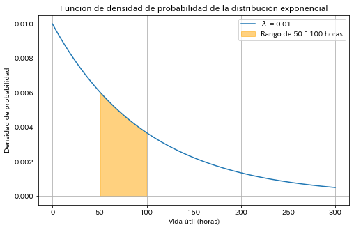

```python
# Parámetros de la distribución
lambda_param = 1 / 100  # Tasa de falla λ = 1/100 horas

# Cálculo de la vida media y la varianza
mean_lifetime = 1 / lambda_param
variance_lifetime = 1 / (lambda_param ** 2)

# Cálculo de la probabilidad de que la vida útil esté entre 50 y 100
probability_50_to_100 = np.exp(-lambda_param * 50) - np.exp(-lambda_param * 100)

# Mostrar resultados
print(f"Vida media: {mean_lifetime:.2f} horas")
print(f"Varianza: {variance_lifetime:.2f} horas²")
print(f"Probabilidad de vida entre 50 y 100 horas: {probability_50_to_100:.3f}")

# Crear gráfico
x = np.linspace(0, 300, 500)  # Rango de 0 a 300 horas
pdf = lambda_param * np.exp(-lambda_param * x)  # Función de densidad de de probabilidad de distribución exponencial

plt.figure(figsize=(8, 5))
plt.plot(x, pdf, label=f"λ = {lambda_param}")
plt.fill_between(x, pdf, where=(x >= 50) & (x <= 100), color='orange', alpha=0.5, label="Rango de 50 ~ 100 horas")
plt.title("Función de densidad de probabilidad de la distribución exponencial")
plt.xlabel("Vida útil (horas)")
plt.ylabel("Densidad de probabilidad")
plt.grid(True)
plt.legend()
plt.show()
```

## 03-04 Distribución bidimensional Covarianza

二次元分布と共分散

### 1. Distribución bidimensional: Distribución de dos variables aleatorias correspondientes.

Coeficiente de correlación: Cantidad que representa la relación entre dos variables aleatorias

Coeficiente de correlación

相関係数

$ \rho (X, Y) = \frac{Cov(X, Y)}{\sqrt{V(X) \cdot V(Y) }} = \frac{Cov(X,Y)}{D(X) \cdot D(Y)}$

$ V(aX+bY) = a^2V(X) + b^2V(Y) + 2abCov(X,Y) $

El coeficiente de correlación tiene las siguientes propiedades importantes 相関係数の重要な性質: No cambia si se le suma una constante o si se multiplica por una constante. Además, dado que el coeficiente de correlación es inherentemente independiente de las unidades, tampoco depende de la varianza de la distribución.

$ \rho (aX +b, cY+d) = \rho (X, Y) $

$ -1 \leq \rho(X,Y) \leq 1 $

[Audio_6](https://drive.google.com/file/d/1mzLH0FUzMtSKaHWui8gQodI-z4PeJu1Q/view?usp=drive_link)

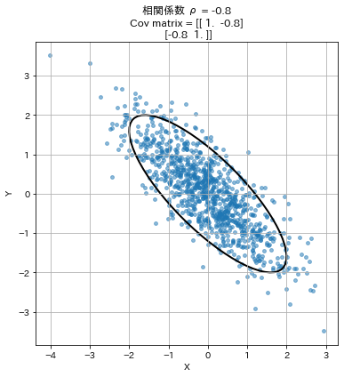

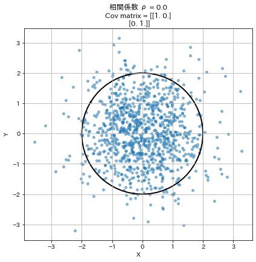

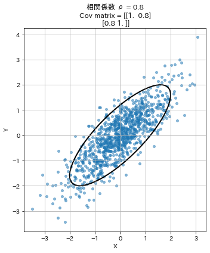

```python
from matplotlib.patches import Ellipse
import math

# Utility: draw covariance ellipse
def draw_cov_ellipse(ax, mean, cov, n_std=2.0):
    # Eigenvalues and eigenvectors
    vals, vecs = np.linalg.eigh(cov)
    # Sort
    order = vals.argsort()[::-1]
    vals, vecs = vals[order], vecs[:, order]

    # Width and height of ellipse
    width, height = 2 * n_std * np.sqrt(vals)

    # Angle of rotation (in degrees)
    theta = math.degrees(np.arctan2(*vecs[:, 0][::-1]))

    ellipse = Ellipse(xy=mean, width=width, height=height,
                      angle=theta, fill=False, linewidth=2)
    ax.add_patch(ellipse)

# Parameters
mean = [0, 0]
correlations = [-0.8, 0.0, 0.8]
n = 1000

for rho in correlations:
    cov = np.array([[1, rho],
                    [rho, 1]])

    # Generate samples
    samples = np.random.multivariate_normal(mean, cov, size=n)

    # Create plot (one figure per correlation)
    fig, ax = plt.subplots(figsize=(6, 6))
    ax.scatter(samples[:, 0], samples[:, 1], alpha=0.5, s=15)

    # Draw 2-std covariance ellipse
    draw_cov_ellipse(ax, mean, cov, n_std=2)

    # Labels and title
    ax.set_title(f'相関係数 ρ = {rho:.1f}\nCov matrix = {cov}')
    ax.set_xlabel('X')
    ax.set_ylabel('Y')
    ax.set_aspect('equal', adjustable='box')
    ax.grid(True)
    plt.tight_layout()
    plt.show()
```

### 2. Varianza de una distribución bidimensional

二次元分布の分散

## 3.3

２種類の加工部品A、Bを別々に製造しこれらを組み合わせ（Aの中にBをはめ込む）部品を作る工程がある。部品Aは外輪で、その内径Xは正規分布 $ N(40,3^2) $に従う、部品Bは軸で、その外形Yは正規分布$ N(30, 1^2) $ に従っている。組み合わせ作業では、Xの大きな部品Aには、Yの大きな部品Bを、Xの小さな部品Aには、Yの小さな部品Yを組み合わせるようにしており、その組み合わせはXとYの母相関係数で0.6であることが分かっている。外輪と軸の隙間である$ Z = X - Y $ の寸法の分散を求めよ。

$ V(X) = 3^2, \qquad V(Y) = 1^2, \qquad \rho(X, Y) = 0.60 $

$ V(Z) = V(X - Y) = V(X) + V(Y) - 2 \times Cov(X,Y) $

$ \qquad = V(X) + V(Y) - 2 \times \rho(X,Y) \sqrt{V(X) \cdot V(Y)} = 6.4 $

```python
# Parámetros dados
mu_X = 40   # Media de X（diámetro interior de la pieza A）
sigma_X = np.sqrt(9)  # Desviación estándar de X
mu_Y = 30   # Media de Y（diámetro exterior de la pieza B）
sigma_Y = np.sqrt(1)  # Desviación estándar de Y
rho_XY = 0.6  # Coeficiente de correlación entre X e Y

# Cálculo de la media y la varianza de Z = X - Y
mu_Z = mu_X - mu_Y  # Media de Z
var_Z = sigma_X**2 + sigma_Y**2 - 2 * rho_XY * sigma_X * sigma_Y  # Varianza de Z

# Visualización del resultado
print(f"La varianza de Z = X - Y:  {var_Z:.2f} ")
```

```
La varianza de Z = X - Y:  6.40
```

Si las dimensiones de un producto se determinan por la longitud de la parte A + la longitud de la parte B, una combinación puramente aleatoria dará como resultado una mayor variabilidad en la dimensión final Z.

Experimento 1: Combinación aleatoria

- La parte azul del gráfico.

Experimento 2: Combinación por rangos

Principio estadístico básico:

- Cuando la dimensión Z = A + B, la variabilidad (varianza= de Z es:
  - $ Var(Z) = Var(A) + Var(B) + 2 \rho \sigma_A \sigma_B $
- Esto significa que si la correlación es negativa, la variabilidad disminuye.

En resumen:

- La variabilidad del producto cambia según cómo se combinen las partes.
- La correlación negativa (combinar piezas grandes con pequeñas) genera un efecto positivo.
- Se puede lograr una mejora en la calidad con ajustes simples en el proceso de trabajo.

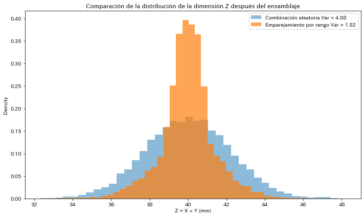

```python
# Cnfiguración básica
mu_x, sigma_x = 30, 2
mu_y, sigma_y = 10, 1
n = 10000

# Generar las piezas A y B, cada una de una distribución normal（sin correlación）
X = np.random.normal(mu_x, sigma_x, n)
Y = np.random.normal(mu_y, sigma_y, n)

# Clasificar en rangos grande, mediano y pequeño（33% cada uno）
def assign_rank(arr):
    q1 = np.quantile(arr, 1/3)
    q2 = np.quantile(arr, 2/3)
    return np.digitize(arr, bins=[q1, q2])  # 0:pequeño, 1:mediano, 2:grande

rank_X = assign_rank(X)
rank_Y = assign_rank(Y)

# Reglas de emparejamiento : G:X→P:Y, M:X→M:Y, P:X→G:Y
matched_Y = np.zeros_like(Y)
for rx in [0, 1, 2]:
    # Rango de Y correspondiente
    ry = 2 - rx
    # Índices de X e Y correspondientes
    x_idx = np.where(rank_X == rx)[0]
    y_idx = np.where(rank_Y == ry)[0]

    # Reorganizar y combinar aleatoriamente (igualar cantidades)
    np.random.shuffle(x_idx)
    np.random.shuffle(y_idx)
    n_match = min(len(x_idx), len(y_idx))

    matched_Y[x_idx[:n_match]] = Y[y_idx[:n_match]]
    # Lax X restantes usan las Y originales (las no combinadas)

# Z después de la combinación (con emparejamiento por rango aplicado)
Z_matched = X + matched_Y
Z_random = X + Y  # Emparejamiento aleatorio normal

# Comparación de la varianza
var_matched = np.var(Z_matched, ddof=1)
var_random = np.var(Z_random, ddof=1)

# Comparar con un histograma
plt.figure(figsize=(10, 6))
plt.hist(Z_random, bins=40, alpha=0.5, density=True, label=f'Combinación aleatoria Var ≈ {var_random:.2f}')
plt.hist(Z_matched, bins=40, alpha=0.7, density=True, label=f'Emparejamiento por rango Var ≈ {var_matched:.2f}')
plt.xlabel('Z = X + Y (mm)')
plt.ylabel('Density')
plt.title('Comparación de la distribución de la dimensión Z después del ensamblaje')
plt.legend()
plt.tight_layout()
plt.show()
```

## 03-05 Ley de grandes números y Teorema central del límite

大数の法則と中心極限定理

### 1. Ley de los grandes números

La ley de los grandes números establece que, a medida que el número de repeticiones de un experimento aumenta, la media de los resultados obtenidos se acerca al valor esperado o la media teórica. Es decir, cuanto más veces se repite un experimento, más probable es que la media de los resultados se aproxime al valor verdadero que debería esperarse.

Por ejemplo, al lanzar una moneda muchas veces, la frecuencia relativa de caras y cruces se acercará al valor teórico de 50% para cada uno a medida que el número de lanzamientos aumenta.

Existen dos versiones de la ley de los grandes números: la versión débil y la versión fuerte. La diferencia principal está en el tipo de convergencia que describen, pero ambas indican que la media muestral se estabiliza conforme aumenta el tamaño de la muestra.

### 2. Teorema central de límite

El teorema central de límite establece que, independientemente de la distribución de los datos originales, cuando tomamos suficiente muestras de una población, la distribución de la media muestral de esas muestras tenderá a ser una **distribución normal** (también llamada distribución de Gauss) a medida que el tamaño de la muestra crece. Esto es cierto incluso si los datos originales no siguen una distribución normal.

En otras palabras, si tomamos repetidas muestras de una población y calculamos sus medias, la distribución de esas medias será aproximadamente normal, siempre que el tamaño de las muestras sea lo suficientemente grande, independientemente de cómo se distribuyen los datos originales.

Este teorema es la base de muchas técnicas estadísticas y nos permite usar la distribución normal como aproximación para realizar inferencias sobre una población, incluso cuando no conocemos su distribución exacta.

Ambos conceptos son fundamentales en la teoría de probabilidad, y explican por qué las distribuciones de los promedios tienden a normalizarse y cómo se puede prever el comportamiento de los resultados en experimentos repetidos.

[Audio_7](https://drive.google.com/file/d/1BK4bO6WVTZpZf5mNQNL1p7Ylm_JKHrxr/view?usp=drive_link)

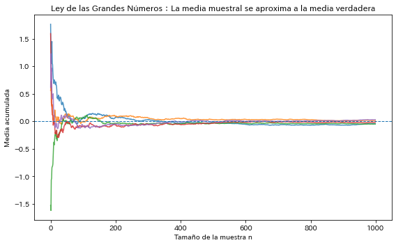

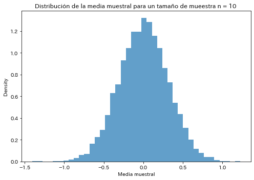

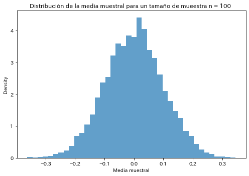

```python
# --------------------------
# Law of Large Numbers demo
# --------------------------

np.random.seed(0)  # reproducibility

# Parameters
true_mean = 0
true_std = 1
n_max = 1000         # largest sample size
n_trials = 5         # number of independent sequences to show
reps = 10000         # repetitions for histogram demo

# Generate data for cumulative‐mean convergence plot
data = np.random.normal(loc=true_mean, scale=true_std, size=(n_trials, n_max))
cum_means = np.cumsum(data, axis=1) / np.arange(1, n_max + 1)

# --- Chart 1: convergence of sample mean ---------------------------
plt.figure(figsize=(8, 5))
for i in range(n_trials):
    plt.plot(cum_means[i], alpha=0.8)

plt.axhline(true_mean, linestyle='--', linewidth=1)
plt.xlabel("Tamaño de la muestra n")
plt.ylabel("Media acumulada")
plt.title("Ley de las Grandes Números：La media muestral se aproxima a la media verdadera")
plt.tight_layout()
plt.show()

# --- Chart 2 & 3: distribution of sample mean for different n -------
for n in [10, 100]:
    sample_means = np.mean(
        np.random.normal(loc=true_mean, scale=true_std, size=(reps, n)),
        axis=1
    )

    plt.figure(figsize=(7, 5))
    plt.hist(sample_means, bins=40, density=True, alpha=0.7)
    plt.xlabel("Media muestral")
    plt.ylabel("Density")
    plt.title(f"Distribución de la media muestral para un tamaño de mueestra n = {n} ")
    plt.tight_layout()
    plt.show()
```

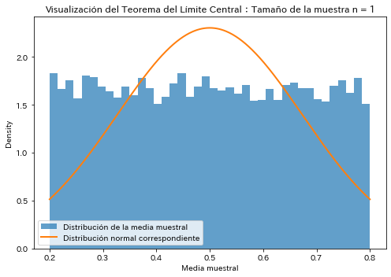

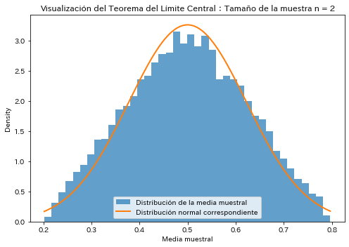

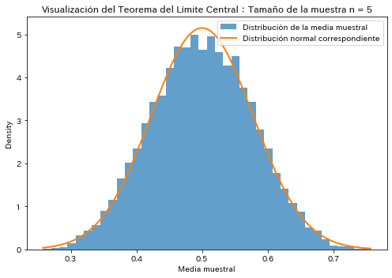

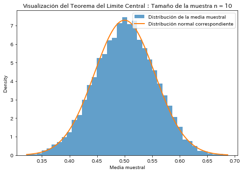

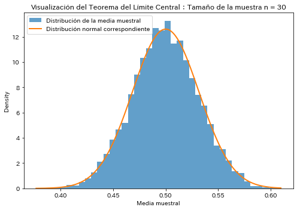

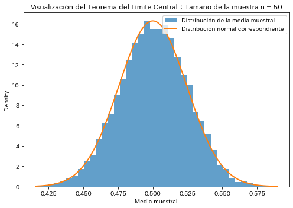

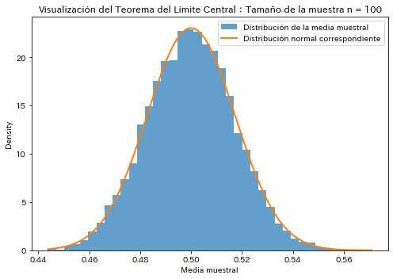

```python
# ----- Central Limit Theorem visualization -----
np.random.seed(0)

'''
# Skewed base distribution: exponential(mean=1, var=1)
mean_true = 1.0
var_true = 1.0
'''

# Uniform(a=0,b=1): mean = (a+b)/2, variance = (b-a)**2/12
a = 0.2
b = 0.8
mean_true = (a + b) / 2
var_true = (b - a)**2 / 12

sample_sizes = [1,2,5, 10, 30, 50, 100]  # increasing n
reps = 10000  # number of replications for each n

for n in sample_sizes:
    # Generate replications of sample means
    #samples = np.random.exponential(scale=mean_true, size=(reps, n))
    samples = np.random.uniform(low=a, high=b, size=(reps, n))
    means = samples.mean(axis=1)

    # Theoretical normal pdf for comparison
    sd_theoretical = np.sqrt(var_true / n)
    x_vals = np.linspace(means.min(), means.max(), 400)
    normal_pdf = (1 / (sd_theoretical * np.sqrt(2 * np.pi))) * \
                 np.exp(-0.5 * ((x_vals - mean_true) / sd_theoretical) ** 2)

    # Plot histogram and normal curve
    plt.figure(figsize=(7, 5))
    plt.hist(means, bins=40, density=True, alpha=0.7, label="Distribución de la media muestral")
    plt.plot(x_vals, normal_pdf, linewidth=2, label="Distribución normal correspondiente")
    plt.title(f"Visualización del Teorema del Límite Central：Tamaño de la muestra n = {n}")
    plt.xlabel("Media muestral")
    plt.ylabel("Density")
    plt.legend()
    plt.tight_layout()
    plt.show()
```

## Por favor, responda a las preguntas del examen de práctica a través del siguiente enlace.

[Simulacro de examen](https://forms.gle/MBEmTVFPqUEy5jNn8)

## 8.1-1

確率変数Xは区間(0,4)の範囲の一様分布に従い、確率変数Yは区間(0,6)の範囲の一様分布に従い互いに独立とする。下記を求めよ。

1. Xの期待値 $ E(X) $ と分散 $ V(X) $
2. $ X^2 $ の期待値 $ E(X^2) $
3. $ X+Y $ の期待値と分散
4. $ X-Y $ の期待値と分散

La variable aleatoria X sigue una distribución uniforme en el intervalo (0,4), y la variable aleatoria Y sigue una distribución uniforme en el intervalo (0,6), siendo independientes entre sí. Calcular lo siguiente:

1. Esperanza de X: $ E(X) $ y varianza de X: $ V(X) $
2. Esperanza de $ X^2 $: $ E(X^2) $
3. Esperanza y varianza de $ X+Y $
4. Esperanza y varianza de $ X-Y $
1. La función de densidad de probabilidad x es:
- $ f(x) = 1/(b-a) $
- $ E(X) = \int_a^b x \cdot \frac{1}{(b-a)} dx $
- $ E(X^2) = \int_a^b x^2 \cdot \frac{1}{(b-a)} dx $
- $ V(X) = E\{ (X-\mu)^2 \} = E(X^2) - \{ E(X)\}^2 $
- $ E(X+Y) = E(X) + E(Y) $
- $ V(X+Y) = V(X) + V(Y) $
- $ E(X-Y) = E(X) - E(Y) $
- $ V(X-Y) = V(X) + V(Y) $

```python
from fractions import Fraction

#
def uniform_distribution_properties(a, b):
    # E(X) = (a + b) / 2
    mean = Fraction(a + b, 2)
    # E(X^2) = (a^2 + ab + b^2) / 3
    mean_square = Fraction(a**2 + a*b + b**2, 3)
    # V(X) = ((b - a)^2) / 12
    variance = Fraction((b - a) ** 2, 12)
    return mean, mean_square, variance

# X ~ U(0, 4)
a_X, b_X = 0, 4
E_X, E_X2, V_X = uniform_distribution_properties(a_X, b_X)

# Y ~ U(0, 6)
a_Y, b_Y = 0, 6
E_Y, E_Y2, V_Y = uniform_distribution_properties(a_Y, b_Y)

# X + Y
E_X_plus_Y = E_X + E_Y
V_X_plus_Y = V_X + V_Y

# X - Y
E_X_minus_Y = E_X - E_Y
V_X_minus_Y = V_X + V_Y

#
print(f"E(X): {E_X}")
print(f"E(X^2): {E_X2}")
print(f"V(X): {V_X}")

print(f"E(X + Y): {E_X_plus_Y}")
print(f"V(X + Y): {V_X_plus_Y}")

print(f"E(X - Y): {E_X_minus_Y}")
print(f"V(X - Y): {V_X_minus_Y}")
```

```
E(X): 2
E(X^2): 16/3
V(X): 4/3
E(X + Y): 5
V(X + Y): 13/3
E(X - Y): -1
V(X - Y): 13/3
```

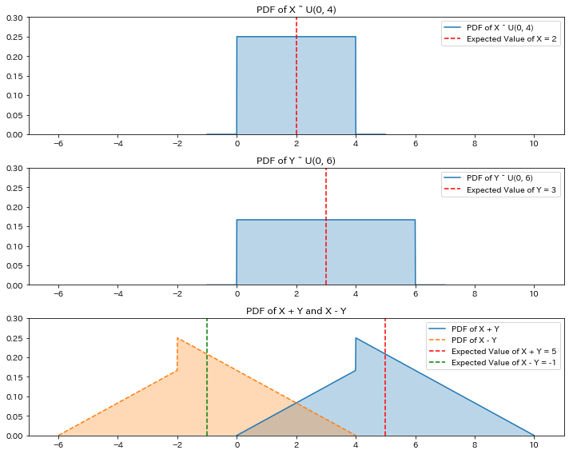

```python
# X ~ U(0,4), Y ~ U(0,6)
x_min, x_max = 0, 4
y_min, y_max = 0, 6

fx = 1 / (x_max - x_min)  # f_X(x) = 1/4
fy = 1 / (y_max - y_min)  # f_Y(y) = 1/6

# X + Y のPDF (理論値)
def f_x_plus_y(z):
    if 0 <= z <= 4:
        return z / 24
    elif 4 < z <= 10:
        return (10 - z) / 24
    else:
        return 0

# X - Y のPDF (理論値)
def f_x_minus_y(w):
    if -6 <= w <= -2:
        return (6 + w) / 24
    elif -2 < w <= 4:
        return (4 - w) / 24
    else:
        return 0

# z, w
z_values = np.linspace(0, 10, 1000)
w_values = np.linspace(-6, 4, 1000)

# Cálculo PDF
f_z_values = np.array([f_x_plus_y(z) for z in z_values])
f_w_values = np.array([f_x_minus_y(w) for w in w_values])

# Graph
x = np.linspace(-1, 11, 1000)  #
y = np.linspace(-1, 10, 1000)  #

# X ~ U(0, 4)  PDF
def uniform_pdf(x, a, b):
    return np.where((x >= a) & (x <= b), 1 / (b - a), 0)

#
fig, axs = plt.subplots(3, 1, figsize=(10, 8))

# X ~ U(0, 4)  PDF
x_vals = np.linspace(a_X - 1, b_X + 1, 1000)
pdf_X = uniform_pdf(x_vals, a_X, b_X)
axs[0].plot(x_vals, pdf_X, label=f'PDF of X ~ U({a_X}, {b_X})')
axs[0].fill_between(x_vals, pdf_X, alpha=0.3)
axs[0].axvline(E_X, color='r', linestyle='--', label=f'Expected Value of X = {E_X}')
axs[0].set_title('PDF of X ~ U(0, 4)')
axs[0].legend()

# Y ~ U(0, 6)  PDF
y_vals = np.linspace(a_Y - 1, b_Y + 1, 1000)
pdf_Y = uniform_pdf(y_vals, a_Y, b_Y)
axs[1].plot(y_vals, pdf_Y, label=f'PDF of Y ~ U({a_Y}, {b_Y})')
axs[1].fill_between(y_vals, pdf_Y, alpha=0.3)
axs[1].axvline(E_Y, color='r', linestyle='--', label=f'Expected Value of Y = {E_Y}')
axs[1].set_title('PDF of Y ~ U(0, 6)')
axs[1].legend()

axs[2].plot(z_values, f_z_values, label=f'PDF of X + Y')
axs[2].plot(w_values, f_w_values, label=f'PDF of X - Y', linestyle='--')
axs[2].fill_between(z_values, f_z_values, alpha=0.3)
axs[2].fill_between(w_values, f_w_values, alpha=0.3)
axs[2].axvline(E_X_plus_Y, color='r', linestyle='--', label=f'Expected Value of X + Y = {E_X_plus_Y}')
axs[2].axvline(E_X_minus_Y, color='g', linestyle='--', label=f'Expected Value of X - Y = {E_X_minus_Y}')
axs[2].set_title('PDF of X + Y and X - Y')
axs[2].legend()

for ax in axs[:]:
  ax.set_xlim(-7,11)
  ax.set_ylim(0,0.3)

plt.tight_layout()
plt.show()
```

和 $ Z = X + Y $ の確率密度関数： 畳み込み積分でX+Yの理論分布の計算を行う

Función de densidad de probabilidad de la zuma $ Z = X + Y $: Realizar el cálculo de la distribución teórica de X + Y mediante la integral de convolución

$ fX+Y(z) = \int_0^4 fX(x) fY(z-x) dx $

$ 0 \leq z \leq 4: f(z) = \frac{z}{24} $

$ 4 < z \leq 10: f(z)=\frac{10-z}{24} $

## 8.1-2

2種類の部品A(寸法X)、B(寸法Y)を別々に製造し、これらを組み合わせて製品(寸法Z=X+Y)を作る工程がある。

部品AのXは正規分布 $ N(30, 2^2) $ に従い、部品BのYは正規分布 $ N(10, 1^2) $ に従う。

組み合わせ作業では、Xの大きな部品AにはYの小さな部品Bを組み合わせ、Xの小さな部品AにはYの大きな部品Bを組み合わせており、その組み合わせの実施状況はXとYの母相関係数で $ -0.75 $であることがわかっている。

寸法Zの分散を求めよ。

Hay un proceso de fabricación en el que se producen por separado dos tipos de componentes. A (dimensión X) y B (dimensión Y), y luego se combinan para formar un producto como la dimensión $ Z = X + Y $.

La dimensión X del componente A sigue una distribución normal $ N(30,2^2) $, y la dimensión Y del componente B sigue una distribución normal $ N(10, 1^2) $.

Durante el proceso de ensamblaje, los componentes A con un valor alto de X se combinan con los componentes B con un valor bajo de Y, y viceversa. Se sabe que el coeficiente de correlación poblacional entre X e Y es de $ -0.75 $.

Determinar la varianza de la dimensión Z.

La varianza de la variable aleatoria $ a(X) + b(Y) $ usando la covarianza $ Cov(X,Y) $ :

$ V(aX + bY) = a^2 V(X) + b^2 V(Y) + 2ab Cov(X,Y) $

Coeficiente de correlación poblacional $ \rho $ :

$ \rho(X,Y) = \frac{Cov(X,Y)}{\sqrt{V(X) \cdot V(Y)}}$

$ V(aX + bY) = a^2 V(X) + b^2 V(Y) + 2ab Cov(X,Y) $

$ \qquad = a^2 V(X) + b^2 V(Y) + 2ab \cdot \rho(X,Y) \sqrt{V(X) \cdot V(Y)} $

```python
import math

# Datos de entrada
sigma_X_squared = 4  # Varianza de X (σ_X^2)
sigma_Y_squared = 1  # Varianza de Y (σ_Y^2)
rho = -0.75  # Coeficiente de correlación entre X e Y

# Cálculo de la desviación estándar
sigma_X = math.sqrt(sigma_X_squared)  # Desviación estándar de X
sigma_Y = math.sqrt(sigma_Y_squared)  # Desviación estándar de Y

# Cálculo de la covarianza
cov_XY = rho * sigma_X * sigma_Y

# Cálculo de la varianza de Z
V_Z = sigma_X_squared + sigma_Y_squared + 2 * cov_XY

print(f"la varianza de Z V(Z): {V_Z}")
```

```
la varianza de Z V(Z): 2.0
```

## 8 .2

機械部品を製造している工程がある。この部品のある特性値は、母平均100.0、母標準偏差2.0の正規分布に従っている。

Hay un proceso de fabricación de componentes mecánicos. Un cierto valor característico de estos componentes sigue una distribución normal con una medida poblacional de 100.0 y una desviación estándar población de 2.0

```python
import scipy.stats as stats

# Media poblacional y desviación estándar poblacional
mu = 100.0
sigma = 2.0
```

1. サンプルをランダムに１個採取した。このサンプルの特性値が、99.0以上かつ102.0以下である確率を求めよ。
1. Se tomó una muestra aleatoria de un solo componente. Calcula la probabilidad de que el valor característico de esta muestra sea mayor o igual a 99.0 y menor o igual a 102.0.

```python
# Rango para calcular la probabilidad de que esté entre 99.0 y 102.0
lower_bound = 99.0
upper_bound = 102.0

# Calcular la probabilidad usando la función de distribución acumulada (CDF)
probability = stats.norm.cdf(upper_bound, mu, sigma) - stats.norm.cdf(lower_bound, mu, sigma)

# Mostrar el resultado
print(f"la probabilidad de que el valor de la característica esté entre 99.0 y 102.0 : {probability:.2f}")
```

```
la probabilidad de que el valor de la característica esté entre 99.0 y 102.0 : 0.53
```

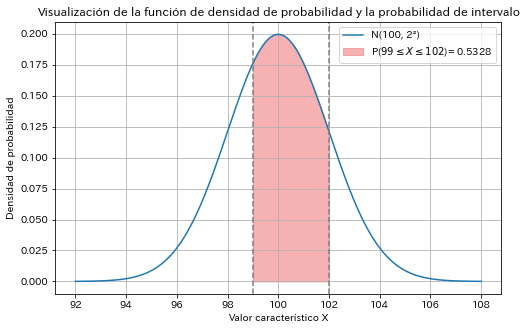

```python
# Valor del eje x
x = np.linspace(mu - 4*sigma, mu + 4*sigma, 500)
pdf = norm.pdf(x, mu, sigma)

# Rango para calcular la probabilidad
lower, upper = 99.0, 102.0
x_fill = np.linspace(lower, upper, 300)
pdf_fill = norm.pdf(x_fill, mu, sigma)

# Calcular la probabilidad
p = norm.cdf(upper, mu, sigma) - norm.cdf(lower, mu, sigma)

# Visualizar
plt.figure(figsize=(8, 5))
plt.plot(x, pdf, label='N(100, 2²)')
plt.fill_between(x_fill, pdf_fill, color='lightcoral', alpha=0.6,
                 label=r'P($ 99 \leq X \leq 102 $)' + f'= {p:.4f}')
plt.axvline(lower, color='gray', linestyle='--')
plt.axvline(upper, color='gray', linestyle='--')
plt.title('Visualización de la función de densidad de probabilidad y la probabilidad de intervalo')
plt.xlabel('Valor característico X')
plt.ylabel('Densidad de probabilidad')
plt.grid(True)
plt.legend()
plt.show()
```

1. サンプルをランダムに4個採取した。これらのサンプルの特性値の平均値が、99.5以上かつ100.5以下である確率を求めよ。
1. Se tomaron aleatoriamente cuatro muestras. Calcula la probabilidad de que la media de los valores característicos de estas muestras sea mayor o igual a 99.5 y menor o igual a 100.5.

La media muestral $ \bar{x} $ de una muestra de tamaño $ n $ tomada aleatoriamente de una población $ N(\mu, \sigma^2 )$ que sigue una distribución normal, se distribuye según $ N(\mu, \frac{\sigma^2}{n} ) $

```python
# Tamaño de la muestra
n = 4

# Desviación estándar de la media
sigma_sample_mean = sigma / (n ** 0.5)

# Probabilidad de que la media muestral esté entre 99.5 y 100.5
lower_bound = 99.5
upper_bound = 100.5

# Calcular la probabilidad usando la función de distribución acumalada (CDF)
probability = stats.norm.cdf(upper_bound, mu, sigma_sample_mean) - stats.norm.cdf(lower_bound, mu, sigma_sample_mean)

# Mostrar el resultado
print(f"la probabilidad de que el promedio del valor de la característica de la muestra esté entre 99.5 y 100.5: {probability:.2f}")
```

```
la probabilidad de que el promedio del valor de la característica de la muestra esté entre 99.5 y 100.5: 0.38
```

1. サンプルをランダムに11個採取した。これらのサンプルの特性値の不偏分散Vが1.3以下である確率を求めよ。
1. Se tomaron aleatoriamente once muestras. Calcula la probabilidad de que la varianza insesgada V de los valores característicos de estas muestras sea menor o igual a 1.3.

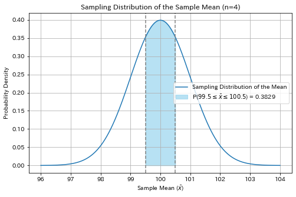

```python
# Tamaño de la muestra
n = 4

# Desviación estándar de la distribución de la media muestral (error estándar)
se = sigma / np.sqrt(n)

# Rango
x = np.linspace(mu - 4*se, mu + 4*se, 500)
pdf = norm.pdf(x, mu, se)

# Rango de probabilidad deseado
x_fill = np.linspace(99.5, 100.5, 300)
pdf_fill = norm.pdf(x_fill, mu, se)

# Calcular la probabilidad
p = norm.cdf(100.5, mu, se) - norm.cdf(99.5, mu, se)

# Visualizacion
plt.figure(figsize=(8, 5))
plt.plot(x, pdf, label='Sampling Distribution of the Mean')
plt.fill_between(x_fill, pdf_fill, color='skyblue', alpha=0.6,
                 label=r'P($ 99.5 \leq \bar{x} \leq 100.5 $)' + f' = {p:.4f}')
plt.axvline(99.5, color='gray', linestyle='--')
plt.axvline(100.5, color='gray', linestyle='--')
plt.title('Sampling Distribution of the Sample Mean (n=4)')
plt.xlabel(r'Sample Mean ($ \bar{x} $)')
plt.ylabel('Probability Density')
plt.legend()
plt.grid(True)
plt.show()
```

La suma de cuadrados de las desviaciones S, estandarizada por la varianza poblacional $ \sigma_x^2 $, sigue una distribución chi-cuadrado $ (\chi^2) $ con $ n-1 $ grados de libertad.

```python
# Tamaño de la muestra
n = 11

# Desviación estándar probacional
sigma = 2.0

# Límite superior de la varianza insesgada
V_upper = 1.3

# Grados de libertad de la distribución chi-cuadrado
df = n - 1

# Varianza de la muestra
sample_variance = (sigma ** 2)

# Calcular la probabilidad de que la varianza insesgada sea menor o igual
# a 1.3 usando la distribución chi-cuadrado
chi2_value = (n - 1) * V_upper / sample_variance
probability = stats.chi2.cdf(chi2_value, df)

# Mostrar el resultado
print(f"la probabilidad de que la varianza insesgada de la muestra sea menor o igual a 1.3 : {probability:.4f}")
```

```
la probabilidad de que la varianza insesgada de la muestra sea menor o igual a 1.3 : 0.0251
```

1. サンプルをランダムに採取した時、これらのサンプルの特性値の不偏分散Vが3.0以下となる確率を25%以下にしたい。この条件を満足する最も少ないサンプル数ｎを求めよ。
1. Cuando se toma una muestra aleatoria, se desea que la probabilidad de que la varianza insesgada $ V $ de los valores característicos de estas muestras sea menor o igual a 3.0 sea del 25% o menos. Determina el tamaño de muestra mínimo $ n $ que satisface esta condición.

```python
# Desviación estándar poblacional
sigma = 2.0

# Límite superior de la varizanza insesgada
V_upper = 3.0

# Probabilidad objetivo
target_probability = 0.25

# Tamaño de muestra inicial
n = 2

# Encontrar el tamaño de muestra mínimo que cumple la condición
while True:
    df = n - 1  # Grado de libertad
    sample_variance = (sigma ** 2)

    # Calcular la probabilidad de que la varianza insesgada se menor o
    # igual a 3.0 usando la distribución chi-cuadrado
    chi2_value = (n - 1) * V_upper / sample_variance
    probability = stats.chi2.cdf(chi2_value, df)

    # Si la probabilidad es menor o igual al objetivo, mostrar el tamaño de
    # muestra actual
    if probability <= target_probability:
        break

    # Aumentar el tamaño de muestra y proceder a la siguiente iteración
    n += 1

# Mostrar el resultado
print(f"el tamaño mínimo de muestra para que la probabilidad de que la varianza \ninsesgada del valor de la característica de la muestra \nsea menor o igual a {V_upper:.1f} sea del {target_probability*100:.1f}% o menos: {n}")
```

```
el tamaño mínimo de muestra para que la probabilidad de que la varianza
insesgada del valor de la característica de la muestra
sea menor o igual a 3.0 sea del 25.0% o menos: 18
```

1. 上限確率 $ P = 1-0.25=0.75 $ に対する $ \phi $ と $ \chi^2 $ の組み合わせの計算表を作成する。
1. Crear una tabla de cálculo de combinaciones de $ \phi $ y $ \chi^2 $ para la probabilidad límite $ P = 1-0.25 = 0.75 $.

$ V = 4 \cdot \chi^2 / (n-1) $

Para satisfacer las condiciones de la pregunta 4, basta con que $ V \geq 3.0 $ en la tabla, de donde se obtiene que $ n = 18 $

```python
def calculate_chi_square(df, P):
    chi2_value = stats.chi2.isf(P, df)
    return chi2_value

tab = pd.DataFrame({"n":[12,17,18,20,26]})
tab["df"] = tab["n"]-1
tab["chi^2"] = calculate_chi_square(tab["df"], 0.75)
tab["V"] = tab["chi^2"]*4/tab["df"]
tab[['chi^2','V']] = tab[['chi^2','V']].apply(lambda c: c.map(lambda x: round(x, 2)))

print("Tabla de cálculo")
tab
```

```
Tabla de cálculo
```

|  | n | df | chi^2 | V |
| --- | --- | --- | --- | --- |
| 0 | 12 | 11 | 7.58 | 2.76 |
| 1 | 17 | 16 | 11.91 | 2.98 |
| 2 | 18 | 17 | 12.79 | 3.01 |
| 3 | 20 | 19 | 14.56 | 3.07 |
| 4 | 26 | 25 | 19.94 | 3.19 |

## 8.3

ガラス瓶に洋酒を自動充填している工程があり、充填する洋酒の洋酒の体積を一定になるように制御している。充填された洋酒の体積は母平均 $ 735.0 ml $,母分散 $ 1.0^2 (ml)^2 $ の正規分布に従い、ガラス瓶の内容積は母平均 $ 750.0 ml $、母分散 $ 3.0^2 (ml)^2 $ の正規分布に従っており、互いに独立とする。

En un proceso de llenado automático de licor en botellas de vidrio, se controla el volumen del licor llenado para que sea constante. El volumen del licor llenado sigue una distribución normal con una media poblacional de $ 735.0 ml $ y una varianza poblacional de $ 1.0^2 (ml)^2 $. El volumen interno de las botellas de vidrio sigue una distribución normal con una media poblacional de $ 750.0 ml $ y una varianza poblacional de $ 3.0^2 (ml)^2 $, y ambos son estadísticamente independientes.

1. 充填される洋酒瓶の空隙部の容積の母平均と母分散を求めよ。
1. Determina la media poblacional y la varianza poblacional del volumen de espacio vacío en las botellas de licor llenadas.

La media poblacional del volumen del espacio vacío $ x $ se obtiene restando el volumen de la bebida alcohólica del volumen de la botella de vidrio.

La varianza poblacional de $ x $ se calcula usando el teorema de adición de varianzas.

```python
# Media poblacional del volumen interno de la botella de vidrio y
# del volumen de licor llenado
mean_volume_bottle = 750.0  # Media poblacional del volumen interno de la botella de vidrio (mL)
mean_volume_liquor = 735.0  # Media poblacional del volumen del licor (mL)

# Calcular la media poblacional del volumen del espacio vacío
mean_void_volume = mean_volume_bottle - mean_volume_liquor

# Mostrar el resultado
print(f"Media poblacional del volumen del espacio vacío en \nlas botellas de licor lenadas: {mean_void_volume} mL")

# Varianza poblacional del volumen interno de la botella de vidrio y
# del volumen de licor llenado
variance_volume_bottle = 3.0**2  # Varianza poblacional del volumen interno de la botella de vidrio (mL^2)
variance_volume_liquor = 1.0**2  # Varianza poblacional del volumen del licor (mL^2)

# Calcular la varianza poblacional del volumen del espacio vacío
variance_void_volume = variance_volume_bottle + variance_volume_liquor

# Mostrar el resultado
print(f"Varianza poblacional del volumen del espacio vacío en \nlas botellas de licor llenadas: {variance_void_volume} (mL^2)")
```

```
Media poblacional del volumen del espacio vacío en
las botellas de licor lenadas: 15.0 mL
Varianza poblacional del volumen del espacio vacío en
las botellas de licor llenadas: 10.0 (mL^2)
```

1. 空隙部の容積が $ 9.0 ml $ 以上かつ $ 21.0 ml $ 以下の瓶を適合品としている。不適合品の発生する確率を求めよ。
1. Se consideran productos conformes las botellas cuyo volumen del espacio vacío está entre $ 9.0 ml $ y $ 21.0 ml $. Calcula la probabilidad de que se generen productos no conformes.

Calcular cuántas desviaciones estándar poblacionales (de 3.16) separan a 9.0 y 21.0 de la media poblacional del volumen del espacio vacío (15.0)

```python
from scipy.stats import norm

# Media y varianza poblacional del volumen del licor
mu_X = 735.0
sigma_X = 1.0

# Media y varianza poblacional del volumen interno de la botella de vidrio
mu_Y = 750.0
sigma_Y = 3.0

# Media y varianza poblacional del volumen del espacio vacío
mu_Z = mu_Y - mu_X
sigma_Z = np.sqrt(sigma_X**2 + sigma_Y**2)

# Calcular la probabilidad de que el volumen del espacio vacío esté entre
# 9.0 ml y 21.0 ml
lower_bound = 9.0
upper_bound = 21.0

# Calcular la probabilidad de que el volumen del espacio vacío esté entre 9.0 ml y 21.0 ml
probabilidad = norm.cdf(upper_bound, mu_Z, sigma_Z) - norm.cdf(lower_bound, mu_Z, sigma_Z)

# Probabilidad de productos no conformes (fuera de los límites)
probabilidad_no_conforme = 1 - probabilidad

# Mostrar el resultado
print(f'La probabilidad de que el volumen del espacio vacío esté fuera de ese rango \n(productos no conformes) es: {probabilidad_no_conforme*100:.1f}%')
```

```
La probabilidad de que el volumen del espacio vacío esté fuera de ese rango
(productos no conformes) es: 5.8%
```

1. ある時、特殊なセンサーを導入し空隙部の容積が一定になるように充填量を制御する方式に変更した。空隙部の容積の母平均は15.0 mlとする。この時、空隙部の容積の規格が9.0 ml以上かつ21.0 ml以下である確率を求め、不適合品の発生する確率が1.0 %以下になるように空隙部の母分散を求めよ。
1. En un momento dado, se introdujo un sensor especial y se cambió el método de control del volumen de llenado para que el volumen del espacio vacío sea constante. Se supone que la media poblacional del volumen del espacio vacío es de 15.0 ml. En este caso, calcule la probabilidad de que el volumen del espacio vacío entre 9.0 ml y 21.0 ml, y determine la varianza poblacional del volumen del espacio vacío de manera que la probabilidad de que se produzcan productos defectuosos sea inferior al 1.0 %.

Basta con que la probabilidad de que el espacio vacío después del cambio de proceso sea 9.0 y 21.0 sea 0.005, respectivamente.

```python
from scipy.optimize import brentq
import scipy.stats as stats

# Parámetros
mu_X = 735.0  # Media poblacional del volumen del licor
sigma_X = 1.0  # Varianza poblacional del volumen del licor

mu_Y = 750.0  # Media poblacional del volumen interno de la totella de vidrio
sigma_Y = 3.0  # Varianza poblacional de volumen interno de la botella de vidrio

# Nueva media poblacional del volumen del espacio vacío
mu_Z_new = 15.0

# Probabilidad de que el volumen del espacio vacío este 9.0 ml y 21.0 ml,
# garantizando que sea mayor al 99%
lower_bound = 9.0
upper_bound = 21.0
required_probability = 0.99

# Función para calcular la varianza del volumen del espacio vacio
def probability_defective(sigma_Z_squared):
    if sigma_Z_squared <= 0:
        return 1.0  # Valores de varianza menores o iguales a 0 son inválidos

    # Desviación estándar del volumen de espacio vacío Z
    sigma_Z = np.sqrt(sigma_Z_squared)

    # Distribución de probabilidad del volumen del espacio vacío Z
    prob_within_range = stats.norm.cdf(upper_bound, mu_Z_new, sigma_Z) - stats.norm.cdf(lower_bound, mu_Z_new, sigma_Z)

    # Probabilidad de productos defectuosos
    prob_defective = 1 - prob_within_range

    return prob_defective - (1 - required_probability)

# Para garantizar que la varianza sea mayor que 0, se establece un valor mínimo
lower_bound_variance = 0.01

# Evaluar la función para valores mayores o iguales a 0 y buscar la solución
optimal_variance = brentq(probability_defective, lower_bound_variance, 1000)

# Resultados
optimal_std_dev = np.sqrt(optimal_variance)
optimal_prob_defective = probability_defective(optimal_variance) + (1 - required_probability)

# Mostrar resultados
print(f"Varianza poblacional del volumen del espacio vacío: {optimal_variance:.1f} ml^2")
```

```
Varianza poblacional del volumen del espacio vacío: 5.4 ml^2
```

## 8.4

1. $ u $ が正規分布 $ N(0, 1^2) $ に従うとき、$ u^2 $ は自由度 $ \phi = 1 $ の $ \chi^2 $ 分布に従う
1. Si $ u $ sigue una distribución normal $ N(0,1^2) $, entonces $ u^2 $ sigue una distribución $ \chi^2 $ con un grado de libertad $ (\phi = 1) $.

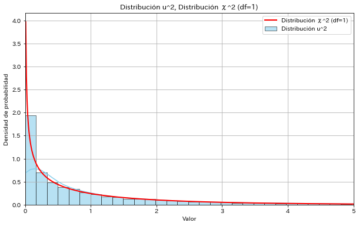

```python
import seaborn as sns
from scipy.stats import chi2, norm

# Tamaño de la muestra
n_samples = 10000

# Generar muestras de la distribución normal N(0, 1^2)
u = np.random.normal(0, 1, n_samples)

# Calcula el cuadrado de u
u_squared = u ** 2

# Superponer la distribución χ^2
x = np.linspace(0, 10, 1000)
chi2_pdf = chi2.pdf(x, df=1)

# Dibujar el histograma
plt.figure(figsize=(10, 6))
sns.histplot(u_squared, bins=100, stat="density", color='skyblue', kde=True, label='Distribución u^2', alpha=0.6)

# Superponer la distribuchio χ^2
plt.plot(x, chi2_pdf, color='red', label='Distribución χ^2 (df=1)', lw=2)

# Decorar el gráfico
plt.title('Distribución u^2, Distribución χ^2 (df=1)')
plt.xlabel('Valor')
plt.ylabel('Densidad de probabilidad')
plt.legend()
plt.grid()
plt.xlim(0, 5)

# Mostrar el gráfico
plt.show()
```

1. $ \phi = \infty $ のｔ分布は、正規分布 $ N(0,1^2) $ と一致する
1. La distribución $ t $ con $ \phi = \infty $ coincide con la distribución normal $ N(0,1^2) $.

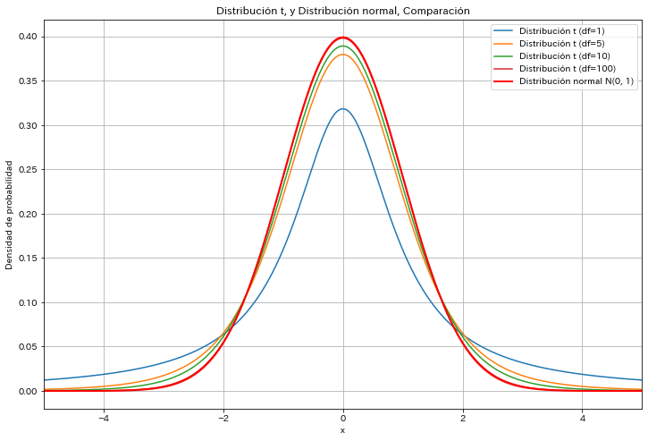

```python
from scipy.stats import t, norm

# Establecer el rango del eje x
x = np.linspace(-5, 5, 1000)

# Configurar los grado sde libertad
degrees_of_freedom = [1, 5, 10, 100]  # 100 representa apoximadamente infinito

# Dibujar el gr[afico]
plt.figure(figsize=(12, 8))

# Dibujar la distribución t y la distribución normal
for df in degrees_of_freedom:
    plt.plot(x, t.pdf(x, df), label=f'Distribución t (df={df})')

# Dibujar la distribución normal
plt.plot(x, norm.pdf(x, 0, 1), label='Distribución normal N(0, 1)', color='red', lw=2)

# Decorar gráfico
plt.title('Distribución t, y Distribución normal, Comparación')
plt.xlabel('x')
plt.ylabel('Densidad de probabilidad')
plt.legend()
plt.grid()
plt.xlim(-5, 5)

# Mostrar el gráfico
plt.show()
```

1. $ t $ が自由度 $ \phi $ の $ t $ 分布に従うとき、$ t^2 $ は自由度 $ \phi_1 = 1 $, $ \phi_2 = \phi $ のF分布に従う
1. Si $ t $ sigue una distribución $ t $ con $ \phi $ grados de libertad, entonces $ t^2 $ sigue una distribución $ F $ con $ \phi_1 $ y $ \phi_2 = \phi $ grados de libertad.

   t(1,P)^2 = F(1, 1:P)

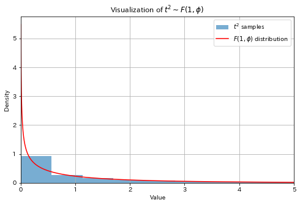

```python
import scipy.stats as stats

# Configurar los grados de libertad
phi = 10  # Grados de libertad de la distribución t
phi1 = 1  # Grados de libertad 1 de la distribución F
phi2 = phi  # Grados de libertad 2 de la distribución F

# Generar muestras de la distribución t
t_samples = np.random.standard_t(df=phi, size=100000)
t_squared_samples = t_samples**2  # Elevar al cuadrado los valores de t

# Calcular la función de densidad de probabilidad teórica de la distribución F
x = np.linspace(0, 5, 1000)
f_pdf = stats.f.pdf(x, phi1, phi2)

# Dibujar el histograma
plt.figure(figsize=(8, 5))
plt.hist(t_squared_samples, bins=500, density=True, alpha=0.6, label=r'$t^2$ samples')
plt.plot(x, f_pdf, 'r-', label=r'$F(1, \phi)$ distribution')
plt.xlim(0,5)

# Decorar el gráfico
plt.xlabel('Value')
plt.ylabel('Density')
plt.title(r'Visualization of $t^2 \sim F(1, \phi)$')
plt.legend()
plt.grid()
plt.show()
```

1. $ \chi^2 $ が自由度 $ \phi $ の $ \chi^2 $ 分布に従うとき、$ \chi^2 / \phi $ は自由度 $ \phi_1 = \phi $, $ \phi_2 = \infty $ のF分布にしたがう
1. Cuando $ \chi^2 $ sigue una distribución $ \chi^2 $ con grados de libertad $ \phi $, entonces $ \chi^2 / \phi $ sigue una distribución F con grados de libertad $ \phi_1 = \phi $ y $ \phi_2 = \infty $.

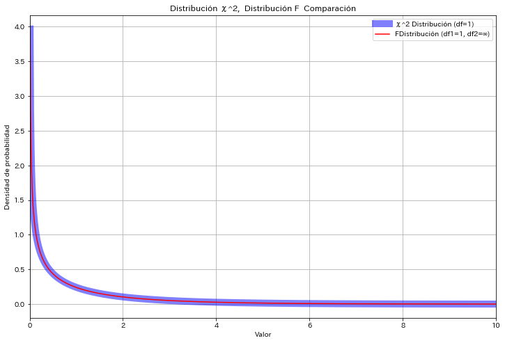

```python
from scipy.stats import chi2, f

# Establecer el rango del eje x
x = np.linspace(0, 10, 1000)

# Configurar el rango de libertad
df_chi2 = 1
df_f1 = 1
df_f2 = 100  # Establecer un valor de grados de libertad cercano a infinito

# Calcular la función de densidad de probabilidad de la distribución χ^2
chi2_pdf = chi2.pdf(x, df_chi2)

# Calcular la función de densidad de probabilidad de la distribución F
f_pdf = f.pdf(x, df_f1, df_f2)

# Dibujar el gráfico
plt.figure(figsize=(12, 8))

# Dibujar la distribución χ^2
plt.plot(x, chi2_pdf, label='χ^2 Distribución (df=1)', linewidth=10, alpha=0.5, color='blue')

# Dibujar la distribución F
plt.plot(x, f_pdf, label='FDistribución (df1=1, df2=∞)', color='red')

# Decorar el gráfico
plt.title('Distribución χ^2,  Distribución F  Comparación')
plt.xlabel('Valor')
plt.ylabel('Densidad de probabilidad')
plt.legend()
plt.grid()
plt.xlim(0, 10)

# Mostrar el gráfico
plt.show()
```

# 8.5

1. 母不適合品率 $ P = 0.1 $ の工程からサンプルを $ n = 4 $ 個ランダムに抜き取った。この時、サンプル中に不適合品が $ x = 1 $ 入っている確率を計算せよ
1. Se extraen aleatoriamente $ n = 4 $ muestras de un proceso con una tasa de productos no conformes de $ P = 0.1 $. Calcule la probabilidad de que haya $ x = 1 $ producto no conforme en la muestra.

```
Probabilidad de que haya 1 artículo defectuoso en la muestra: 0.2916
```

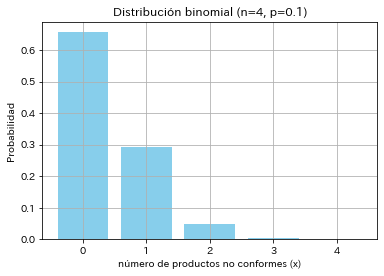

```python
import scipy.stats as stats

# Tasa de defectos en la población p
p = 0.1

# Tamaño de la muestra n
n = 4

# Número de defectuosos x
x = 1

# Calcular la probabilidad de que haya x=1 defectuoso en la muestra utilizando
# la distribución binomial
probability = stats.binom.pmf(x, n, p)

print(f"Probabilidad de que haya 1 artículo defectuoso en la muestra: {probability:.4f}")

# Calcular la probabilidad de cada valor de x en la distribución binomial
# para el rango de x (de 0 a n)
x_values = np.arange(0, n + 1)

# Calcular la probabilidad de cada valor de x en la distribución binomial
# para el rango de x (de 0 a n)
probabilities = stats.binom.pmf(x_values, n, p)

# Crear un gráfico de barras de la distribución binomial
plt.bar(x_values, probabilities, color='skyblue')
plt.xlabel('número de productos no conformes (x)')
plt.ylabel('Probabilidad')
plt.title('Distribución binomial (n=4, p=0.1)')
plt.xticks(x_values)
plt.grid(True)

# Mostrar el gráfico
plt.show()
```

1. 電子部品Eの寿命は、故障率を表すパラメータ $ \lambda = 1/100 (時間^{-1}) $ の指数分布に従っている。この電子部品の寿命Xが100時間から200時間である確率を求めよ。
1. La vida útil del componente electrónico E sigue una distribución exponencial con un parámetro de tasa de fallos $ \lambda = 1/100 (hora^{-1}) $. Calcule la probabilidad de que la vida útil de este componente, X, esté entre 100 horas y 200 horas.

La distribución exponencial se utiliza para representar la distribución del tiempo hasta que ocurren eventos como fallas, y es importante como una distribución de vida útil representativa.

```python
import scipy.stats as stats

# Configuración de parámetros
lambda_param = 1 / 100  # Tasa de fallos λ
t1 = 100  # Límite inferior de la vida útil
t2 = 200  # Límite superior de la vida útil

# Calcular la probabilidad utilizando la función acumulada (CDF)
# de la distribución exponencial
# CDF(x) = 1 - e^(-λx)
prob_t1 = 1 - np.exp(-lambda_param * t1)
prob_t2 = 1 - np.exp(-lambda_param * t2)

# Probabilidad de que la vida útil esté entre 100 y 200 horas
prob = prob_t2 - prob_t1

# Mostrar el resultado
print(f"la probabilidad de que la vida útil esté entre 100 y 200 horas: {prob:.2f}")
```

```
la probabilidad de que la vida útil esté entre 100 y 200 horas: 0.23
```

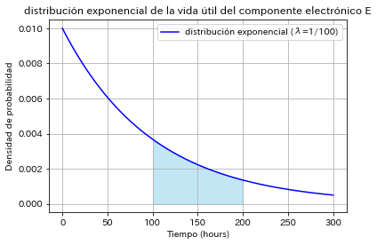

```python
# Establecer el rango de vida útil (de 0 a 300 tiempos)
x_values = np.linspace(0, 300, 500)

# Calcular la función de densidad de probabilidad (PDF) de la distribución exponencial
pdf_values = stats.expon.pdf(x_values, scale=1/lambda_param)

# Crear el gráfico
plt.plot(x_values, pdf_values, label='distribución exponencial (λ=1/100)', color='blue')
plt.fill_between(x_values, pdf_values, where=((x_values >= t1) & (x_values <= t2)), color='skyblue', alpha=0.5)

# Configurar los detalles del gráfico
plt.title('distribución exponencial de la vida útil del componente electrónico E')
plt.xlabel('Tiempo (hours)')
plt.ylabel('Densidad de probabilidad')
plt.legend()
plt.grid(True)

# Mostrar el gráfico
plt.show()
```

```python
notebook_name = 'QCKentei1-3.ipynb'
notebook_name_html = notebook_name.replace(".ipynb",".html")
print(notebook_name + '  ->  ' + notebook_name_html)

!jupyter nbconvert --to html {notebook_name}
```

```
QCKentei1-3.ipynb  ->  QCKentei1-3.html
[NbConvertApp] Converting notebook QCKentei1-3.ipynb to html
[NbConvertApp] Writing 1639436 bytes to QCKentei1-3.html
```